# Good Feet Review Analysis

#1. Exploratory Data Analysis and Preparation

Read in the data

```r
gf = read.csv("GF_mkereviews.csv")
str(gf)
```

```
'data.frame':   121 obs. of  5 variables:
 $ review_ID          : int  1 2 3 4 5 6 7 8 9 10 ...
 $ review_text        : chr  "" "I had a positive experience with my salesperson and my inserts have made a world of difference in my life. So g"| __truncated__ "Started off with misunderstanding however was professionally and timely resolved.\nAm looking forward to using "| __truncated__ "" ...
 $ review_rating      : int  5 5 5 5 5 5 5 5 5 1 ...
 $ review_datetime_utc: chr  "5/14/2022 13:36" "4/5/2022 19:33" "3/30/2022 18:59" "3/24/2022 14:17" ...
 $ review_likes       : int  0 0 0 0 0 0 0 0 0 0 ...
```

```r
summary(gf)
```

```
   review_ID   review_text        review_rating   review_datetime_utc  review_likes
 Min.   :  1   Length:121         Min.   :1.000   Length:121          Min.   :0.0000
 1st Qu.: 31   Class :character   1st Qu.:3.000   Class :character    1st Qu.:0.0000
 Median : 61   Mode  :character   Median :5.000   Mode  :character    Median :0.0000
 Mean   : 61                      Mean   :3.926                       Mean   :0.3554
 3rd Qu.: 91                      3rd Qu.:5.000                       3rd Qu.:0.0000
 Max.   :121                      Max.   :5.000                       Max.   :4.0000
```

```r
gf$review_ID = NULL
```

Randomize the order of the rows

```r
gf = gf[sample(nrow(gf), replace = FALSE),]
```

Converting rating to factor with 1-3 stars as bad and 4-5 as good

```r
gf$review_rating = factor(gf$review_rating)
levels(gf$review_rating) = list("Good"=c("4", "5"), "Bad"=c("1", "2", "3"))
```

```r
library(RColorBrewer)
coul <- brewer.pal(8, "Spectral")
```

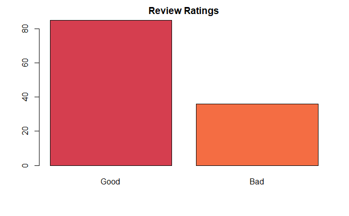

```r
barplot(table(gf$review_rating), col=coul, main = "Review Ratings")
```

Converting review_datetime_utc into a Date variable to look at the time series distribution of when reviewers write their reviews to get an idea of when people visit the store the most.

```r
gf$years = format(as.Date(gf$review_datetime_utc, format="%m/%d/%Y"), format="%Y")
gf$months = format(as.Date(gf$review_datetime_utc, format="%m/%d/%Y"), format="%m")
```

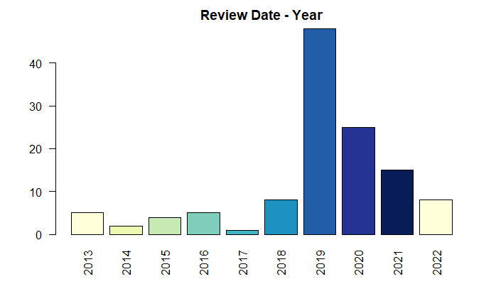

```r
library(car)
coul <- brewer.pal(9, "YlGnBu")
barplot(table(gf$years), col=coul, main="Review Date - Year", las=2)
```

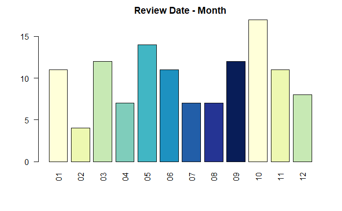

```r
barplot(table(gf$months), col=coul, main="Review Date - Month", las=2)
```

Create a text corpus from review_text variable. Then clean the corpus, that is convert all tweets to lowercase, stem and remove stop words, punctuation, and additional white spaces.

```r
library(tm)
library(SnowballC)
gf_corpus = VCorpus(VectorSource(gf$review_text))
as.character(gf_corpus[[1]])
```

```
[1] "I came into the Good Feet Store 5 weeks ago because I had severe foot and heal pain. While everyone here was so nice and friendly, Filly went out of her way to help me get fitted into the supports that helped me, but the first pair wasn't strong enough for my left foot (the right foot was feeli…
```

```r
gf_corpus_clean = tm_map(gf_corpus, content_transformer(tolower))
gf_corpus_clean = tm_map(gf_corpus_clean, removeNumbers)
gf_corpus_clean = tm_map(gf_corpus_clean, removeWords, stopwords())

replacePunctuation = function(x){
  gsub("[[:punct:]]+", " ", x)
}

gf_corpus_clean = tm_map(gf_corpus_clean, content_transformer(replacePunctuation))

gf_corpus_clean = tm_map(gf_corpus_clean, stemDocument)
gf_corpus_clean = tm_map(gf_corpus_clean, stripWhitespace)
as.character(gf_corpus_clean[[1]])
```

```
[1] "came good feet store week ago sever foot heal pain everyon nice friend filli went way help get fit support help first pair strong enough left foot right foot feel better though came back immedi knew need stronger support far stronger support work good filli also call coupl time check progress s…
```

```r
library(wordcloud)
good = subset(gf, review_rating == "Good")$review_text
bad = subset(gf, review_rating == "Bad")$review_text
```

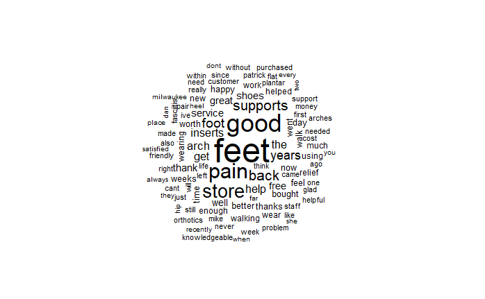

```r
#good
wordcloud(good, max.words = 100, scale = c(3, 0.5), random.order = FALSE)
```

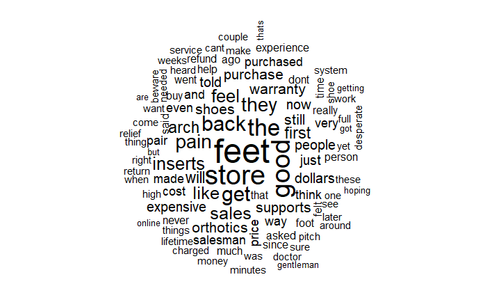

```r
#bad
wordcloud(bad, max.words = 100, scale = c(3, 0.5), random.order = FALSE)
```

```r
myTdm = as.matrix(TermDocumentMatrix(gf_corpus_clean))
FreqMat = data.frame(ST = rownames(myTdm),
                     Freq = rowSums(myTdm),
                     row.names=NULL)
#head(FreqMat)
ordered_freq = FreqMat[order(-FreqMat$Freq),]
ordered_freq
```

|  | ST | Freq |
| --- | --- | --- |
| 226 | feet | 84 |
| 263 | good | 62 |
| 447 | pain | 50 |
| 635 | store | 48 |
| 647 | support | 35 |
| 50 | back | 34 |
| 283 | help | 33 |
| 255 | get | 30 |
| 36 | arch | 29 |
| 311 | insert | 27 |

[output cut: 749 more lines]

# 3. Document Term Matrix and Training/Test sets

```r
gf_dtm = DocumentTermMatrix(gf_corpus_clean)

gf_dtm_train = gf_dtm[1:72, ]
gf_dtm_test = gf_dtm[73:121, ]

gf_train_labels = gf[1:72, ]$review_rating
gf_test_labels = gf[73:121, ]$review_rating
```

```r
gf_dtm
```

```
<<DocumentTermMatrix (documents: 121, terms: 759)>>
Non-/sparse entries: 2184/89655
Sparsity           : 98%
Maximal term length: 14
Weighting          : term frequency (tf)
```

```r
gf_freq_words = findFreqTerms(gf_dtm_train, 5)
gf_dtm_freq_train = gf_dtm_train[, gf_freq_words]
gf_dtm_freq_test = gf_dtm_test[, gf_freq_words]
```

```r
gf_dtm_freq_train
```

```
<<DocumentTermMatrix (documents: 72, terms: 77)>>
Non-/sparse entries: 593/4951
Sparsity           : 89%
Maximal term length: 8
Weighting          : term frequency (tf)
```

We will be using Naive Bayes Classifier which takes in categorical features. We will conver the numeric counts of the appearances of a word in document term matrix to “Yes” or “No” to fit these requirements.

```r
convert_counts <- function(x) {
x = ifelse(x > 0, "Yes", "No")
}
gf_train = apply(gf_dtm_freq_train, MARGIN = 2,
convert_counts)

gf_test = apply(gf_dtm_freq_test, MARGIN = 2,
convert_counts)
```

# 4. Naive Bayes Classifier

```r
library(caret)
model = train(gf_train, gf_train_labels, "nb", trControl=trainControl(method="cv", number=10, classProbs = TRUE,
summaryFunction = twoClassSummary))
```

```r
model
```

```
Naive Bayes

72 samples
77 predictors
 2 classes: 'Good', 'Bad'

No pre-processing
Resampling: Cross-Validated (10 fold)
Summary of sample sizes: 65, 65, 64, 65, 65, 65, ...
Resampling results across tuning parameters:

  usekernel  ROC   Sens  Spec
  FALSE      0.79  0.91  0.55
   TRUE      0.79  0.91  0.55

Tuning parameter 'fL' was held constant at a value of 0
Tuning parameter 'adjust' was held constant at a value of 1
ROC was used to select the optimal model using the largest value.
The final values used for the model were fL = 0, usekernel = FALSE and adjust = 1.
```

```r
table(predict(model$finalModel, gf_test)$class, gf_test_labels)
```

```
      gf_test_labels
       Good Bad
  Good   29   9
  Bad     3   8
```

```r
library(ROCR)
gf_predictions_prob=predict(model, gf_test, type = "prob")
head(gf_predictions_prob)
```

|  | Good | Bad |
| --- | --- | --- |
| 73 | 9.993829e-01 | 0.0006171156 |
| 74 | 8.504935e-08 | 0.9999999150 |
| 75 | 9.985524e-01 | 0.0014475500 |
| 76 | 9.993829e-01 | 0.0006171156 |
| 77 | 9.993364e-01 | 0.0006636222 |
| 78 | 9.993829e-01 | 0.0006171156 |

```r
pred_yes_gf = prediction(gf_predictions_prob$Good, gf_test_labels)
```

```r
performance(pred_yes_gf, measure = "auc")@y.values
```

```
[[1]]
[1] 0.7840074
```